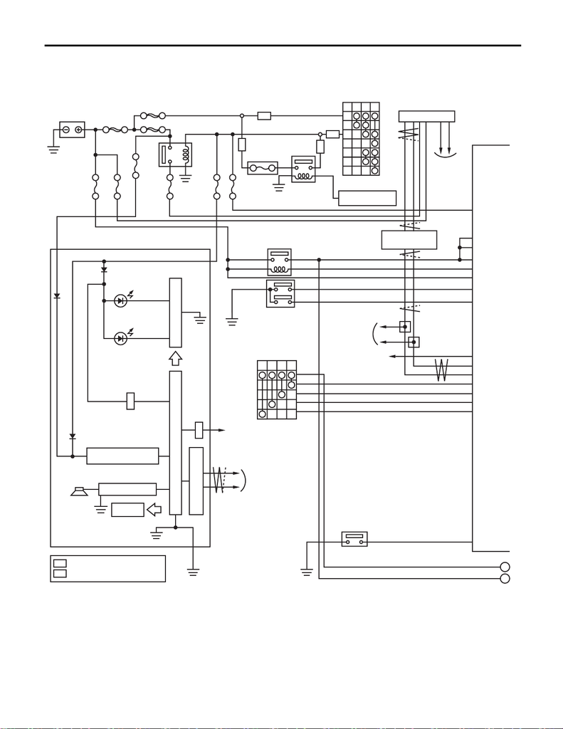

WI-148

CVT Control System

WIRING SYSTEM

16.CVT Control System

A: WIRING DIAGRAM

ECM

WI-44349

PRND

2

1

I/F

I/F

OP

OP

WP

WP

WP

OP

29

38

37

36

43

44

35

18

19

34

25

40

24

8

41

J/C

J/C

TFT

AWD

20

OFF ACC

ON ST

TCM

SBF-6

SBF-8

: WITHOUT PUSH BUTTON START

: WITH PUSH BUTTON START

IGNITION SWITCH

SELECT LEVER

SPEAKER

DRIVE CIRCUIT

ATF

TEMPERATURE

CAN TRANSCEIVER

& RECEIVER

DRIVE CIRCUITMICRO COMPUTER

FUSE HOLDER

KEYLESS ACCESS

CM

IG RELAY 1

(PUSH BUTTON

START)

SATELLITE SWITCH (SI-DRIVE)

CAN COMMUNICATION

M/B FUSE No. 13

M/B FUSE No. 12

BODY

INTEGRATED UNIT

STOP LIGHT SWITCH

CAN

COMMUNICATION

PADDLE SHIFT SWITCH

COMBINATION METER

F/B FUSE No. 12

F/B FUSE

No. 2

F/B FUSE No. 7

F/B FUSE

No. 4

SELF SHUT RELAY

DATA LINK CONNECTOR

IG 2

RELAY

BATTERY

POWER SUPPLY

CIRCUIT

INHIBITOR SWITCH

MAIN

SBF

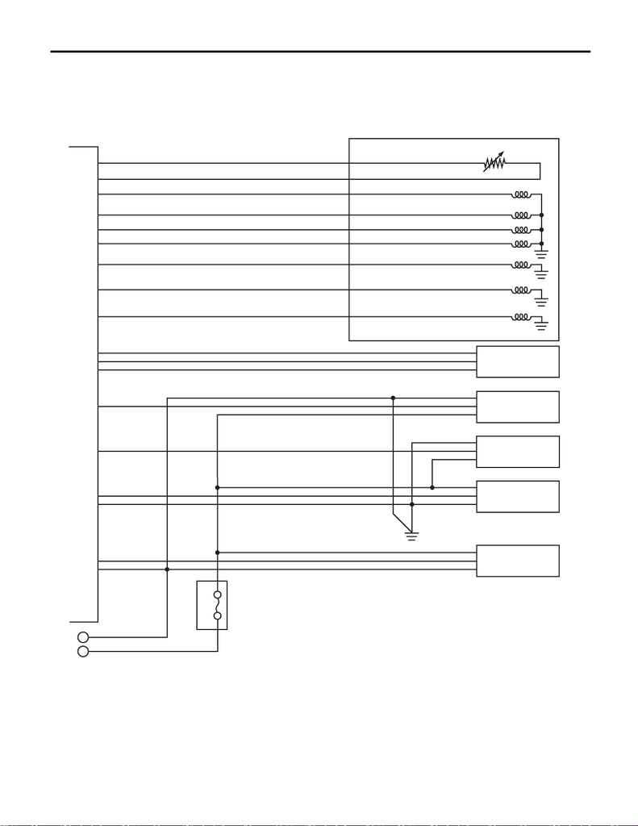

WI-149

CVT Control System

WIRING SYSTEM

WI-44350

1

2

6

1

48

15

47

30

31

16

32

33

TCM

5

2

12

11

13

26

14

42

FUSE HOLDER

7.5A

PRIMARY DOWN SOLENOID

PRIMARY UP SOLENOID

SECONDARY SOLENOID

F & R SOLENOID

LOCK-UP DUTY SOLENOID

CONTROL VALVE BODY

LOCK-UP ON/OFF SOLENOID

ATF TEMPERATURE SENSOR

AWD SOLENOID

SECONDARY

SPEED SENSOR

SECONDARY

PRESSURE SENSOR

FRONT WHEEL

SPEED SENSOR

REAR WHEEL

SPEED SENSOR

PRIMARY

SPEED SENSOR

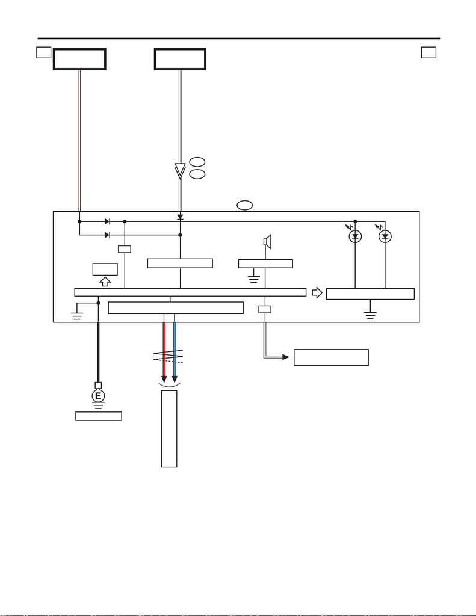

WI-150

CVT Control System

WIRING SYSTEM

WI-44351

a a

3

i10

I/F

i229

B551

I/F

AWD

38

R33

L32

GR 31

TFT

BB

W/L

W/L

W/L

BR/W

BR/W

20

40

SPEAKER

DRIVE CIRCUIT

FB-12

F/B FUSE NO. 2

(IG)

FB-18

F/B FUSE NO. 7

(B)

POWER SUPPLY CIRCUIT

CAN TRANSCEIVER & RECEIVER

MICRO COMPUTER

ATF

TEMPERATURE

DRIVE CIRCUIT

REF. TO GND [e]

REF. TO ENGINE ELECTRICAL

SYSTEM [1c] [2c]

COMBINATION METER

REF. TO CAN COMMUNICATION

SYSTEM [b]

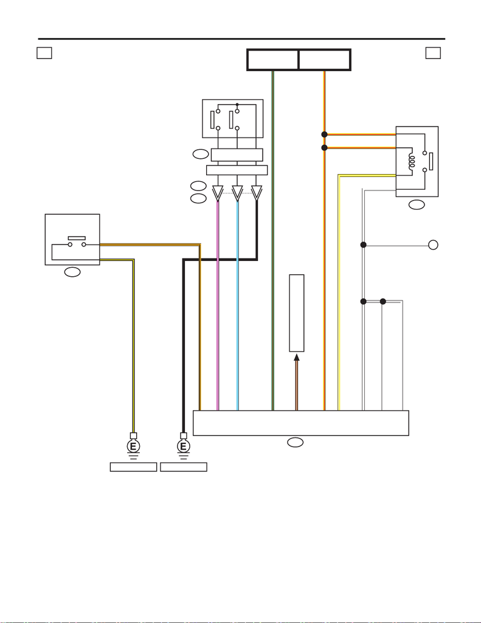

WI-151

CVT Control System

WIRING SYSTEM

TCM

WI-44352

b b

1

8

2

B116

B/Y8

B

B/Y

G/R

Y/R

O/B7

SB

B

V/W

ST4

ST1

B68

UP

DOWN

G/R41

B54

W24

W8

Y/W25

Y/R34

W40

SB18

BR/W29

20 O/B

19 V/W

Y/R

Y/R

W

Y/W

W

A

15

B220

16

14

17

3

1

4

SELF SHUT

RELAY

PADDLE SHIFT SWITCH

ROLL

CONNECTOR

LO/MANUAL

MODE

SWITCH

SELECT LEVER

MB-26

M/B FUSE NO. 12

(B)

FB-38

F/B FUSE NO. 12

(IG)

REF. TO STOP LIGHT SYSTEM

[1a]

REF. TO GND [b]REF. TO GND [d]

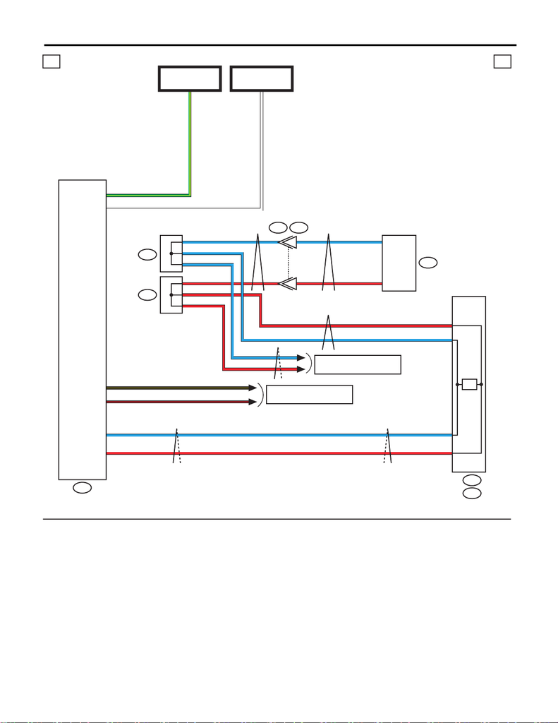

WI-152

CVT Control System

WIRING SYSTEM

WI-44353

c c

B40

B54

I/F

B281B:

i84C:

14 L

4 B/Y

8 G/Y

G/Y

W

1

C27R

C35L

B28L

B20R

6R

5 B/R

16 W

i232

i233

44L

43R

1L

1L

1L

1R

1R

1R

J/C

J/C

TCM

7

6

i229 B551

REF. TO ENGINE ELECTRICAL

SYSTEM [1g] [2g]

REF. TO CAN COMMUNICATION

SYSTEM [b]

DATA LINK

CONNECTOR

BODY INTEGRATED

UNIT

: TERMINAL No. OPTIONAL ARRANGEMENT

MB-27

M/B FUSE NO. 13

(B)

FB-32

F/B FUSE NO. 4

(IG)

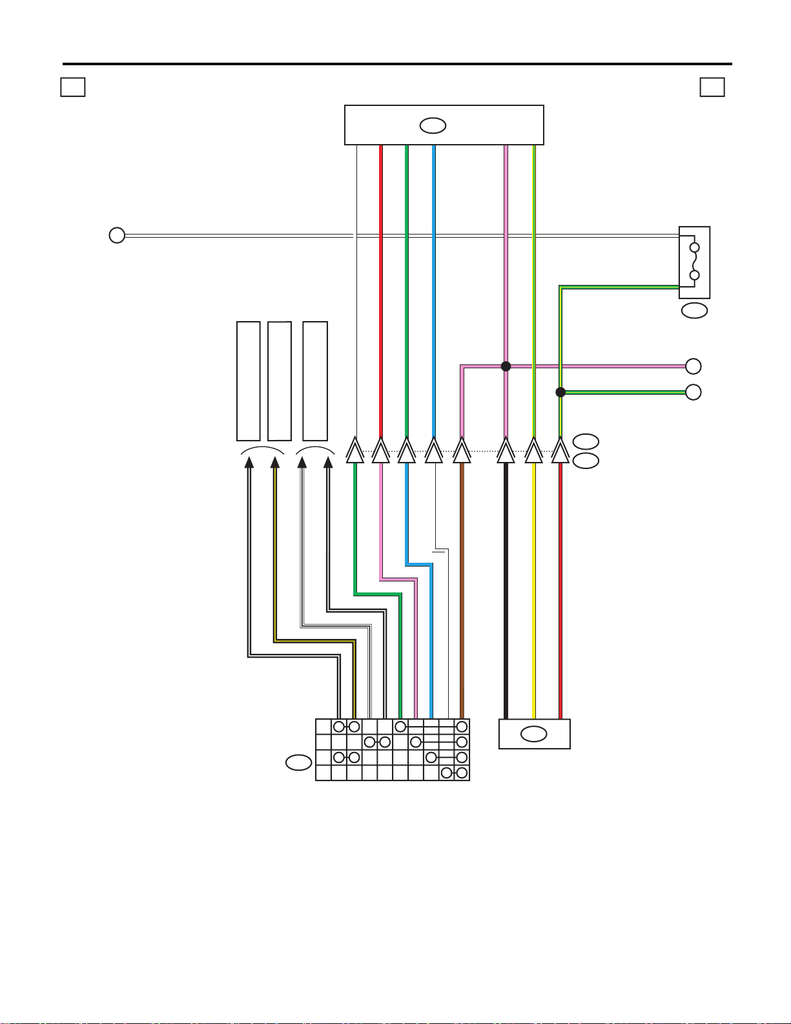

WI-153

CVT Control System

WIRING SYSTEM

WI-44354

d d

3

2

1

8

4

7

6

5

T3

B12

B550

B

C

B/W9

B/Y6

W/B8

B/W7

G2

P5

L3

W4

BR1

20G/Y

6WW

B54

T7

R

W

G

L

38

37

36

35

B/W

B/Y

W/B

B/W

P

R

N

D

R

W

G

P

G

L

L

W

AT1

A

42P

14Y/G

B3

Y2

R

B

Y

R

P

Y/G

G/Y1

P

P

G/Y

BR

TCM

FUSE

HOLDER

7.5A

PRIMARY SPEED

SENSOR

REF. TO STARTER SYSTEM

[1a] [2a]

INHIBITOR

SWITCH

REF. TO ENGINE ELECTRICAL

SYSTEM [1e] [2e]

REF. TO BACK-UP LIGHT

SYSTEM [1a]

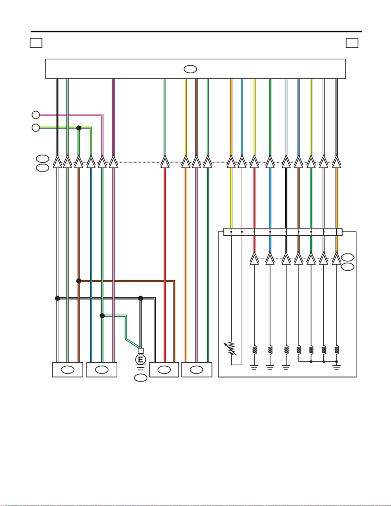

WI-154

CVT Control System

WIRING SYSTEM

G/W

WI-44355

e e

B11

T4

20

8

10

11

7

13

12

17

14

18

16

19

5

9

3

1

6

2

4

1

3

5

6

7

2

8

AT4

GT

B

C

T11

T31

B/W

26B

P

G/Y

13LG

B/W1

LG2

BR

B/W

11LG/BLG/BR/W

LG

BR

B

LG

G/Y3

AT7

B/W1

R/W2

BR3

AT5

12V

L/B1

G/W3

P

L/B

G/W

P

G/Y

P

V2

AT6

33Y/B

5BR

2G/W

Y/R1

P2

G/B

Y/R

P

G/B

Y/B

BR

G/W3

6OY

1L/WW

32YR

16G/RL

31W/LB

30L/RBR

47Y/LG

15R/WGR

48B/WO

O

L/W

Y

G/R

W/L

L/R

Y/L

R/W

B/W

R

L

B

BR

G

GR

O

B54

TCM

ATF TEMPERATURE SENSOR

CONTROL VALVE BODY

SECONDARY SOLENOID

LOCK-UP ON/OFF SOLENOID

AWD SOLENOID

PRIMARY UP SOLENOID

PRIMARY DOWN SOLENOID

F & R SOLENOID

LOCK-UP DUTY SOLENOID

SECONDARY

PRESSURE

SENSOR

FRONT WHEEL

SPEED SENSOR

SECONDARY

SPEED SENSOR

REAR WHEEL

SPEED SENSOR

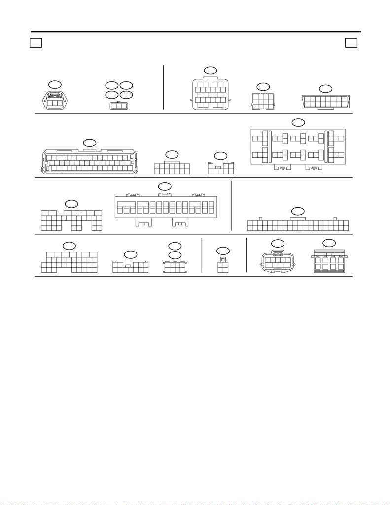

WI-155

CVT Control System

WIRING SYSTEM

LIST OF CONNECTORS

RELAY HOLDER

FUSE HOLDER

f f

B40

B281

(GR)

B54

i10

B116

B220

B:

i84

T7

i233

i232

B11

B12

AT1

T11

B550

B68

(

B

)

C:

(

GR

)

(

B

)

(

B

)

(

B

)

i229

(

B

)

2

1

3

567

12 34

9

10 11 12

17 18 19 20

8

13 14 15 16

5

9

1

6

10

2

7

11

3

8

12

4

1

9

8

16

2

10

7

15

3

11

6

14

4

12

5

13

10 11 12 13 14 15 16

33 34 35 36 37 38 39 40 41 42 43 44 45 46 47 48

3

42

156

7

13 1411

12

9

10

8

123

45678

10 11

12

13

14 15

16

18

19 21 22

20

17

24

5

3

17

9

8

6

32 33

34

35

28262423

25

27

29

30

31

36 37

38

40

41 43 44

42

39

5672134

29

10 11 12 13 14 15

2524

16

30

98

17 18 19

20

28

21 22 23

3231

26 27

33 34 35

91

2

232221 262524201918

4

13

12

17

3

16

6

15

587

14

10 11

11 12

9

10

7856341

2

15 1613 14 19

18

20

21 22 23 24 26

25

27 28 29 30 31 32 33 34 35 36 37 38 39 40

17

19

18

21

20

2322 24 25 26

17

1

23

4

56

27

28 29 30

31 32 33 34 35

798

151413121110 16

12 345

6789

10 11 12

78

5

6

34

21

1

78

69

2345

ST4

12

34

123

AT6

(B)

AT4

(B)

AT5

(GR)

AT7

(B)

13

4

6

78

2

5

WI-44356